# IC-Case 31 - Summary of Data Analysis

Reliability and Factor Analysis for R3 and R6

Author

Willy Su

Published

November 24, 2026

# 1 Data Preparation

This analysis examines the reliability and construct validity of two multi-item scales in Case 31:

- R3: Attitude toward Employee Proficiency (Q3–Q6)
- R6: Attitude toward Operational Effectiveness (Q31–Q34)

## 1.1 Variable Selection

```r
r3_items <- efcu |>
  select(q3, q4, q5, q6)

r6_items <- efcu |>
  select(q31, q32, q33, q34)

dim(efcu)
```

```
[1] 128  53
```

```r
summary(r3_items)
```

```
       q3              q4              q5              q6
 Min.   :3.000   Min.   :2.000   Min.   :3.000   Min.   :2.000
 1st Qu.:4.000   1st Qu.:4.000   1st Qu.:4.000   1st Qu.:4.000
 Median :4.000   Median :4.000   Median :4.000   Median :4.000
 Mean   :4.352   Mean   :4.312   Mean   :4.078   Mean   :4.078
 3rd Qu.:5.000   3rd Qu.:5.000   3rd Qu.:5.000   3rd Qu.:5.000
 Max.   :5.000   Max.   :5.000   Max.   :5.000   Max.   :5.000
```

```r
summary(r6_items)
```

```
      q31             q32             q33             q34
 Min.   :1.000   Min.   :2.000   Min.   :2.000   Min.   :1.000
 1st Qu.:4.000   1st Qu.:3.000   1st Qu.:3.000   1st Qu.:3.000
 Median :4.000   Median :4.000   Median :4.000   Median :4.000
 Mean   :3.945   Mean   :3.719   Mean   :3.594   Mean   :3.461
 3rd Qu.:4.000   3rd Qu.:4.000   3rd Qu.:4.000   3rd Qu.:4.000
 Max.   :5.000   Max.   :5.000   Max.   :5.000   Max.   :5.000
```

# 2 R3: Attitude toward Employee Proficiency

## 2.1 Exploratory Factor Analysis

Exploratory factor analysis is conducted on Q3–Q6 to examine whether the four items measure a single underlying construct.

### 2.1.1 KMO and Bartlett’s Test

```r
psych::KMO(r3_items)
```

```
Kaiser-Meyer-Olkin factor adequacy
Call: psych::KMO(r = r3_items)
Overall MSA =  0.78
MSA for each item =
  q3   q4   q5   q6
0.76 0.73 0.84 0.79
```

```r
psych::cortest.bartlett(
  cor(r3_items),
  n = nrow(r3_items)
)
```

```
$chisq
[1] 263.6114

$p.value
[1] 5.045872e-54

$df
[1] 6
```

### 2.1.2 Parallel Analysis

```
Parallel analysis suggests that the number of factors =  1  and the number of components =  NA
```

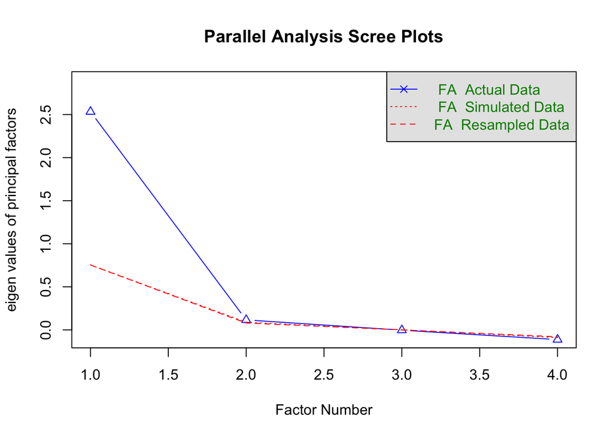

Figure 1: Parallel Analysis for Employee Proficiency

```r
set.seed(123)

psych::fa.parallel(
  r3_items,
  fa = "fa",
  fm = "minres",
  n.iter = 100
)
```

### 2.1.3 Factor Loadings and Communalities

```r
r3_efa <- psych::fa(
  r3_items,
  nfactors = 1,
  rotate = "none",
  fm = "minres"
)

print(r3_efa, digits = 3)
```

```
Factor Analysis using method =  minres
Call: psych::fa(r = r3_items, nfactors = 1, rotate = "none", fm = "minres")
Standardized loadings (pattern matrix) based upon correlation matrix
     MR1    h2    u2 com
q3 0.722 0.522 0.478   1
q4 0.923 0.853 0.147   1
q5 0.792 0.627 0.373   1
q6 0.729 0.531 0.469   1

                 MR1
SS loadings    2.533
Proportion Var 0.633

Mean item complexity =  1
Test of the hypothesis that 1 factor is sufficient.

df null model =  6  with the objective function =  2.112 with Chi Square =  263.611
df of  the model are 2  and the objective function was  0.102

The root mean square of the residuals (RMSR) is  0.047
The df corrected root mean square of the residuals is  0.081

The harmonic n.obs is  128 with the empirical chi square  1.668  with prob <  0.434
The total n.obs was  128  with Likelihood Chi Square =  12.718  with prob <  0.00173

Tucker Lewis Index of factoring reliability =  0.8745
RMSEA index =  0.2045  and the 90 % confidence intervals are  0.1078 0.3196
BIC =  3.014
Fit based upon off diagonal values = 0.995
Measures of factor score adequacy
                                                    MR1
Correlation of (regression) scores with factors   0.952
Multiple R square of scores with factors          0.906
Minimum correlation of possible factor scores     0.813
```

### 2.1.4 Interpretation

The KMO value of 0.78 and significant Bartlett’s test (p < 0.001) indicate that the data are suitable for factor analysis.

Factor loadings range from 0.722 to 0.923, and all communalities exceed 0.50. The one-factor solution explains 63.3% of the total variance, providing evidence of convergent validity.

However, the model fit indices suggest that the one-factor structure should be interpreted with caution. Further reliability and discriminant validity analyses are needed before confirming the composite scale.

# 3 R6: Attitude toward Operational Effectiveness

## 3.1 Exploratory Factor Analysis

Exploratory factor analysis is conducted on Q31–Q34 to assess the convergent validity of the operational effectiveness scale.

### 3.1.1 KMO and Bartlett’s Test

```r
psych::KMO(r6_items)
```

```
Kaiser-Meyer-Olkin factor adequacy
Call: psych::KMO(r = r6_items)
Overall MSA =  0.5
MSA for each item =
 q31  q32  q33  q34
0.49 0.50 0.60 0.46
```

```r
psych::cortest.bartlett(
  cor(r6_items),
  n = nrow(r6_items)
)
```

```
$chisq
[1] 39.33432

$p.value
[1] 6.15472e-07

$df
[1] 6
```

### 3.1.2 Parallel Analysis

```r
set.seed(123)

r6_parallel <- psych::fa.parallel(
  r6_items,
  fa = "fa",
  fm = "minres",
  n.iter = 100
)
```

```
Parallel analysis suggests that the number of factors =  1  and the number of components =  NA
```

```
[1] 1
```

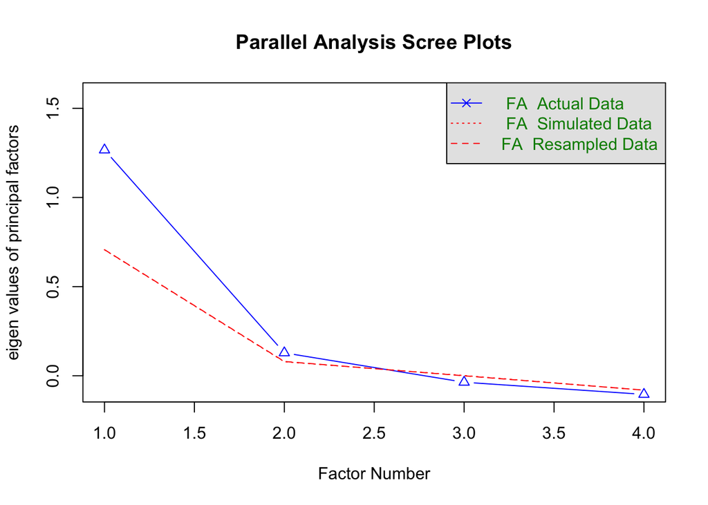

Figure 2: Parallel Analysis for Operational Effectiveness

```r
r6_parallel$nfact
```

### 3.1.3 Factor Loadings and Communalities

```r
r6_efa <- psych::fa(
  r6_items,
  nfactors = 1,
  rotate = "none",
  fm = "minres"
)
print(r6_efa, digits = 3)
```

```
Factor Analysis using method =  minres
Call: psych::fa(r = r6_items, nfactors = 1, rotate = "none", fm = "minres")
Standardized loadings (pattern matrix) based upon correlation matrix
      MR1     h2       u2 com
q31 0.260 0.0674  0.93257   1
q32 1.005 1.0097 -0.00972   1
q33 0.226 0.0513  0.94871   1
q34 0.355 0.1261  0.87386   1

                 MR1
SS loadings    1.255
Proportion Var 0.314

Mean item complexity =  1
Test of the hypothesis that 1 factor is sufficient.

df null model =  6  with the objective function =  0.315 with Chi Square =  39.334
df of  the model are 2  and the objective function was  0.021

The root mean square of the residuals (RMSR) is  0.049
The df corrected root mean square of the residuals is  0.085

The harmonic n.obs is  128 with the empirical chi square  1.854  with prob <  0.396
The total n.obs was  128  with Likelihood Chi Square =  2.657  with prob <  0.265

Tucker Lewis Index of factoring reliability =  0.9405
RMSEA index =  0.05  and the 90 % confidence intervals are  0 0.1911
BIC =  -7.047
Fit based upon off diagonal values = 0.951
Measures of factor score adequacy
                                                    MR1
Correlation of (regression) scores with factors   0.999
Multiple R square of scores with factors          0.999
Minimum correlation of possible factor scores     0.998
```

### 3.1.4 Interpretation

The KMO value of 0.50 indicates marginal sampling adequacy. Although Bartlett’s test is significant (p < 0.001), most factor loadings and communalities are low.

The one-factor solution explains only 31.4% of the variance and produces an ultra-Heywood case. These results indicate weak convergent validity and do not support creating a composite scale at this stage.

# 4 Combined Factor Analysis

## 4.1 Discriminant Validity

A combined factor analysis is conducted on Q3–Q6 and Q31–Q34 to examine whether employee proficiency and operational effectiveness represent two distinct constructs.

### 4.1.1 Parallel Analysis

```r
combined_items <- cbind(r3_items, r6_items)
```

```r
set.seed(123)

combined_parallel <- psych::fa.parallel(
  combined_items,
  fa = "fa",
  fm = "minres",
  n.iter = 100
)
```

```
Parallel analysis suggests that the number of factors =  2  and the number of components =  NA
```

```
[1] 2
```

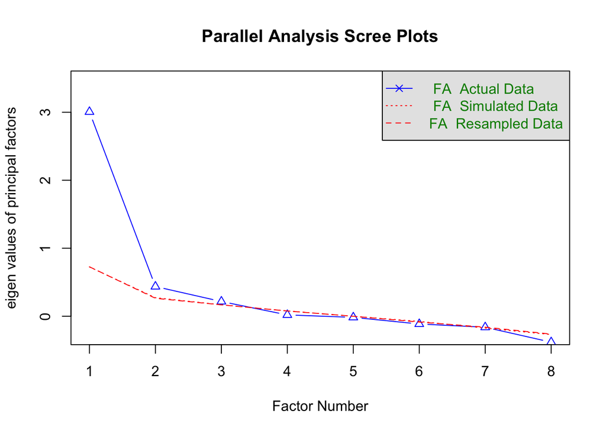

Figure 3: Parallel Analysis for Both Constructs

```r
combined_parallel$nfact
```

### 4.1.2 Two-Factor Solution

```r
combined_efa <- psych::fa(
  combined_items,
  nfactors = 2,
  rotate = "oblimin",
  fm = "minres"
)
print(combined_efa, digits = 3, cutoff = 0)
```

```
Factor Analysis using method =  minres
Call: psych::fa(r = combined_items, nfactors = 2, rotate = "oblimin",
    fm = "minres")
Standardized loadings (pattern matrix) based upon correlation matrix
       MR2    MR1    h2        u2  com
q3   0.757 -0.120 0.515  0.484908 1.05
q4   0.885  0.020 0.799  0.201473 1.00
q5   0.819 -0.010 0.664  0.336444 1.00
q6   0.700  0.139 0.587  0.413090 1.08
q31  0.244  0.144 0.108  0.891532 1.62
q32  0.019  0.993 1.001 -0.000829 1.00
q33  0.382  0.082 0.178  0.822140 1.09
q34 -0.131  0.432 0.158  0.841547 1.18

                        MR2   MR1
SS loadings           2.758 1.252
Proportion Var        0.345 0.156
Cumulative Var        0.345 0.501
Proportion Explained  0.688 0.312
Cumulative Proportion 0.688 1.000

 With factor correlations of
      MR2   MR1
MR2 1.000 0.401
MR1 0.401 1.000

Mean item complexity =  1.1
Test of the hypothesis that 2 factors are sufficient.

df null model =  28  with the objective function =  2.916 0 with Chi Square =  360.099
df of  the model are 13  and the objective function was  0.217
 0
The root mean square of the residuals (RMSR) is  0.042
The df corrected root mean square of the residuals is  0.062
 0
The harmonic n.obs is  128 with the empirical chi square  6.398  with prob <  0.93
 0The total n.obs was  128  with Likelihood Chi Square =  26.488  with prob <  0.0146
 0
Tucker Lewis Index of factoring reliability =  0.9115
RMSEA index =  0.0897  and the 90 % confidence intervals are  0.0389 0.1397 0
BIC =  -36.588
Fit based upon off diagonal values = 0.987
Measures of factor score adequacy
                                                    MR2   MR1
Correlation of (regression) scores with factors   0.924 0.978
Multiple R square of scores with factors          0.854 0.957
Minimum correlation of possible factor scores     0.708 0.913
```

```r
combined_efa$Phi
```

```
         MR2      MR1
MR2 1.000000 0.401046
MR1 0.401046 1.000000
```

### 4.1.3 Factor Diagram

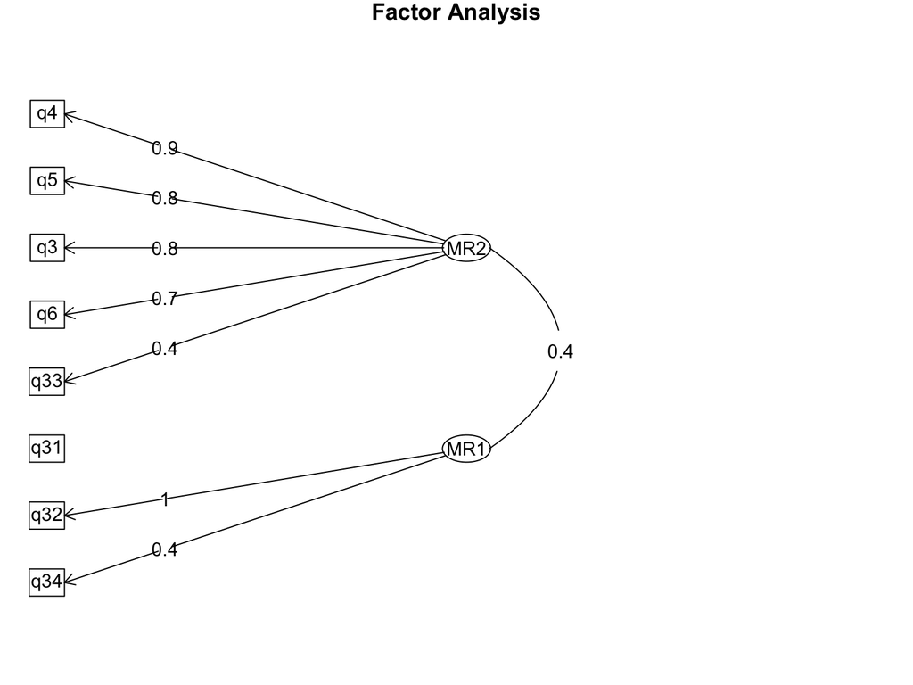

Figure 4: Factor Structure of R3 and R6

```r
psych::fa.diagram(combined_efa)
```

### 4.1.4 Interpretation

Parallel analysis suggests a two-factor structure. R3 items load strongly on the same factor, while R6 items show weak and inconsistent loadings.

The factor correlation is 0.401. However, the ultra-Heywood case and weak R6 loadings indicate that discriminant validity is not fully supported.

# 5 Reliability Analysis

Cronbach’s alpha is used to assess the internal consistency of the R3 and R6 multi-item scales.

## 5.1 R3: Employee Proficiency

```r
r3_alpha <- psych::alpha(r3_items)

print(r3_alpha, digits = 3)
```

```
Reliability analysis
Call: psych::alpha(x = r3_items)

  raw_alpha std.alpha G6(smc) average_r  S/N    ase mean    sd median_r
     0.866     0.869    0.85     0.624 6.65 0.0194 4.21 0.594    0.655

    95% confidence boundaries
         lower alpha upper
Feldt    0.824 0.866 0.900
Duhachek 0.828 0.866 0.904

 Reliability if an item is dropped:
   raw_alpha std.alpha G6(smc) average_r  S/N alpha se    var.r med.r
q3     0.852     0.856   0.799     0.665 5.95   0.0223 0.000562 0.672
q4     0.785     0.790   0.727     0.557 3.77   0.0327 0.007997 0.570
q5     0.824     0.829   0.797     0.618 4.84   0.0276 0.018939 0.672
q6     0.853     0.852   0.804     0.658 5.78   0.0225 0.006100 0.684

 Item statistics
     n raw.r std.r r.cor r.drop mean    sd
q3 128 0.800 0.812 0.731  0.657 4.35 0.659
q4 128 0.906 0.907 0.885  0.823 4.31 0.696
q5 128 0.848 0.853 0.779  0.733 4.08 0.659
q6 128 0.834 0.817 0.732  0.673 4.08 0.790

Non missing response frequency for each item
       2     3     4     5 miss
q3 0.000 0.102 0.445 0.453    0
q4 0.008 0.109 0.445 0.438    0
q5 0.000 0.180 0.562 0.258    0
q6 0.031 0.180 0.469 0.320    0
```

## 5.2 R6: Operational Effectiveness

```r
r6_alpha <- psych::alpha(r6_items)

print(r6_alpha, digits = 3)
```

```
Reliability analysis
Call: psych::alpha(x = r6_items)

  raw_alpha std.alpha G6(smc) average_r   S/N    ase mean    sd median_r
     0.472     0.462    0.44     0.177 0.858 0.0748 3.68 0.458    0.173

    95% confidence boundaries
         lower alpha upper
Feldt    0.305 0.472 0.607
Duhachek 0.325 0.472 0.618

 Reliability if an item is dropped:
    raw_alpha std.alpha G6(smc) average_r   S/N alpha se   var.r  med.r
q31     0.467     0.456   0.397    0.2187 0.840   0.0801 0.02964 0.2242
q32     0.144     0.152   0.111    0.0563 0.179   0.1313 0.00363 0.0439
q33     0.473     0.463   0.419    0.2232 0.862   0.0792 0.03927 0.2781
q34     0.445     0.441   0.353    0.2081 0.788   0.0838 0.00630 0.2242

 Item statistics
      n raw.r std.r r.cor r.drop mean    sd
q31 128 0.538 0.567 0.303  0.195 3.95 0.679
q32 128 0.786 0.764 0.700  0.495 3.72 0.793
q33 128 0.533 0.562 0.272  0.187 3.59 0.681
q34 128 0.613 0.580 0.365  0.229 3.46 0.783

Non missing response frequency for each item
        1     2     3     4     5 miss
q31 0.008 0.000 0.211 0.602 0.180    0
q32 0.000 0.047 0.352 0.438 0.164    0
q33 0.000 0.055 0.352 0.539 0.055    0
q34 0.016 0.109 0.297 0.555 0.023    0
```

## 5.3 Reliability Summary

```r
reliability_summary <- data.frame(
  Scale = c("R3", "R6"),
  Items = c(4, 4),
  Cronbach_Alpha = c(
    r3_alpha$total$raw_alpha,
    r6_alpha$total$raw_alpha
  )
)

knitr::kable(
  reliability_summary,
  digits = 3,
  caption = "Reliability Analysis Summary"
)
```

Reliability Analysis Summary

| Scale | Items | Cronbach_Alpha |
| --- | --- | --- |
| R3 | 4 | 0.866 |
| R6 | 4 | 0.472 |

## 5.4 Interpretation

R3 demonstrates good internal consistency (Cronbach’s alpha = 0.866). Removing any item reduces reliability, supporting the retention of all four items.

R6 demonstrates low internal consistency (Cronbach’s alpha = 0.472). Removing individual items does not substantially improve reliability. Therefore, the R6 items should be analyzed individually.

# 6 Composite Scale Decision and Conclusion

## 6.1 R3: Employee Proficiency

R3 demonstrates good internal consistency (alpha = 0.866) and strong factor loadings. Despite limitations in model fit, Q3–Q6 can be combined into a composite scale by averaging the four items, with caution.

## 6.2 R6: Operational Effectiveness

R6 demonstrates low reliability (alpha = 0.472) and weak convergent validity. Therefore, Q31–Q34 should be analyzed individually rather than combined into a composite scale.

## 6.3 Conclusion

The results support using a composite scale for R3 with caution, but not for R6. Discriminant validity is only partially supported.

# 7 Appendix

## 7.1 GitHub Links

- [GitHub Repository](https://github.com/WillySuu/IC-Case-31--Summary-of-Data-Analysis)
- [GitHub Pages](https://willysuu.github.io/IC-Case-31--Summary-of-Data-Analysis/)